# Aside

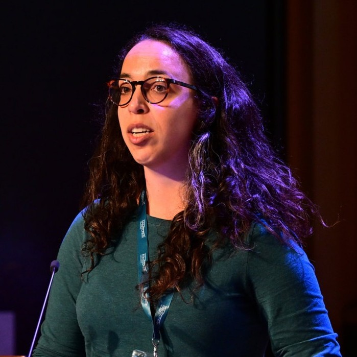

## Contact Info

- brunameneses@gmail.com
- github.com/arbobm
- [/brunameneses](https://www.linkedin.com/in/brunameneses/)
- Cambridge, UK.

## Skills

- R
- ArcGIS
- QGIS
- Tidyverse
- Quarto
- html/css
- shiny app
- LaTeX

## Grants

- [Curso-R](https://curso-r.com/) - Diversity scholarship (jul & nov, 2022)
- [AI Inclusive & Dataquest.io](https://www.ai-inclusive.org/) - Women and other under-represented genders in data science scholarship (jan-jun 2021)

## Disclaimer

This resume was made with the R package [**pagedown**](https://github.com/rstudio/pagedown).

Last updated on 2026-03-19.

# Main

## Bruna Arbo Meneses

### GIS Analyst

I am a conservationist and GIS analyst with experience in systematic conservation planning, connectivity analysis, species distribution modelling, ecological corridor projects, and landscape ecology. I have a broad interest in Ecology, Conservation Biology, and Data Science, especially in landscape planning for biodiversity conservation, aiming to decrease species extinction risk.

## Professional Experience

### Science Officer (Birds & Energy)

BirdLife International

Cambridge, UK

ongoing - 2024

### GIS Technician

National Center for Research and Conservation of Reptiles and Amphibians (RAN/ICMBio)

Goiânia, Brazil

2023 - 2019

- Participates in the process of elaborating the Strategic Areas of the Plans of Action coordinated by the Center, in the execution of PANs actions related to spatial analysis and other on-demand activities.

### GIS Consultant

Instituto Curicaca

Porto Alegre, Brazil

2018 - 2011

- Consultant hired on several projects, general coordinator of the Institution (unpaid role) between February 2015 and August 2016, coordinator of the Landscape Management and Geoprocessing Center between 2016 and 2018. Intern in 2011.

### Administrative assistant

Fundação Estadual de Proteção Ambiental Henrique Luís Roessler (FEPAM)

Porto Alegre, Brazil

2012 - 2011

- Public assistance service for environmental licensing processes opening.

### Undergraduate researcher

Landscape Ecology Lab - UFRGS

Porto Alegre, Brazil

2011 - 2009

## Education

### MBA in Data Science & Analytics

University of São Paulo - Luiz de Queiroz College of Agriculture

Piracicaba, Brazil

2024 - 2022

- Thesis title: Exploring Cumulative Impacts on the Herpetofauna of the River Doce Basin: An Analysis Using Data Science

### M.S., Ecology

Federal University of Rio Grande do Sul (UFRGS)

Porto Alegre, Brazil

2016 - 2014

- Scholarship from Conselho Nacional de Desenvolvimento Científico e Tecnológico (CNPq). Thesis title: Pressão ambiental em bacias hidrográficas do Pampa e sua relação com a ictiofauna.

### B.S., Biological Sciences

Federal University of Rio Grande do Sul (UFRGS)

Porto Alegre, Brazil

2011 - 2006

- Dissertation title: Spatial distribution modeling of three fish species (Characidae) in Atlantic Forest basins, Rio Grande do Sul, Brazil.

## Peer-reviewed articles

### [Fire and herpetofauna in the Pantanal: observations during and post-fire events](http://dx.doi.org/10.37002/biodiversidadebrasileira.v14i4.2556)

Valencia-Zuleta, A.; Richter, A.; Alvarenga, G.V.; Batista, F.R.Q.; Moreira, L.F.B.; **Arbo-Meneses, B.**; Lustosa, A.P.G.; Strüssmann, C.; Abrahão, C.R.; Côrtes, L.G.

N/A

2024

*Biodiversidade Brasileira* v. 14, n. 4

### [NEOTROPICAL FRESHWATER FISHES: A Dataset of Occurrence and Abundance of Freshwater Fishes in the Neotropics.](https://doi.org/10.1002/ecy.3713)

Tonella, Lívia Helena, Renata Ruaro, Vanessa Salete Daga, Diego Azevedo Zoccal Garcia, Oscar Barroso Vitorino Júnior, Tatiana Lobato‐de Magalhães, Roberto Esser dos Reis, et al.

N/A

2023

*Ecology* e3713

### [Movement and longitudinal distribution of a migratory fish (*Salminus brasiliensis*) in a small reservoir in southern Brazil](https://www.scielo.br/j/ni/a/mNShP5gc7nk6tFjLxPBD5nd/?lang=en)

Fries, L.C.C.; Hahn, L.; **Meneses, B.A.**; Câmara, L.F.; Becker, F.G.; Hartz, S.M.

N/A

2019

*Neotropical Ichthyology* v. 17, n. 3.

### [Research on reproduction of natural fish populations in Brazil (2001-2010): a brief overview of trends and gaps](https://www.researchgate.net/publication/255992820_Pesquisa_sobre_reproducao_de_populacoes_naturais_de_peixes_no_Brasil_2001-2010_um_breve_panorama_sobre_tendencias_e_lacunas)

Becker, F.G.; Fries, L.C.C.; Guimarães, T.F.R.; **Meneses, B.A.**

N/A

2010

*Boletim - Sociedade Brasileira de Ictiologia* v. 100, p. 40-44.

## Presentations and Posters

### Mapping avian sensitivity in a seemingly homogeneous desert landscape: A case study from Egypt

**Arbo-Meneses, B.**; Biasotto, L.; Clark, B.; Mohamed, K.; Sherif, N.; Sanghera, S.; Auchincloss, C.; Allinson, T.

N/A

2025

*8th Conference on Wind energy and Wildlife impacts (CWW 2025) - Oral presentation*

### Bird sensitivity index at onshore wind farms: a novel trait-based approach to identify priority species. (Oral presentation)

Biasotto, L.; **Arbo-Meneses, B.**; Sanghera, S.; Clark, B.; Auchincloss, C.; Allinson, T.

N/A

2025

*8th Conference on Wind energy and Wildlife impacts (CWW 2025) - Oral presentation*

### Innovative data integration for mapping avian sensitivity to offshore wind

Clark, B.; Auchincloss, C.; Biasotto, L.; **Arbo-Meneses, B.**; Sanghera, S.;, Vulcano, A.; Celada, C.; Gaibani, G.; Gustin, M.; Maurer, G.; Maguire, G.; Ehmke, G.; Kim, Y.; Allinson, T.

N/A

2025

*8th Conference on Wind energy and Wildlife impacts (CWW 2025)*

### AVISTEP: a sensitivity mapping tool to improve bird conservation in energy planning

**Arbo-Meneses, B.**; Biasotto, L.; Clark, B.; Allinson, T.

N/A

2024

*Wingspan 2024: Partnerships for a bird-friendly energy transition - Oral presentation*

### Is environmental pressure on watersheds related to the ichthyofauna of streams?

**Meneses, B.A.**; Dala-Corte, R.B.; Guimarães, T.F.R.; Becker, F.G.

N/A

2016

*1° Reunião da ABECO e 5° Simpósio de Ecologia Teórica, Gramado.*

### Definition of ecological corridors as a strategy to protect important remnants of wetlands and conservation of the marsh deer (*Blastocerus dichotomus*) in Rio Grande do Sul

Krob, A.; **Meneses, B.A.**; Castilho, C.S.; Ximenes, S.; Kindel, A.; Mahler Jr., J.K.

N/A

2015

*VIII Congresso Brasileiro de Unidades de Conservação, Curitiba. Anais do VIII Congresso Brasileiro de Unidades de Conservação.*

### A preliminary assessment of the fragmentation of brazilian hydrographic systems and implications for the conservation of ichthiofauna

Becker, F.G.; **Meneses, B.A.**; Brack, I.V.; Lopes, K.G.D.

N/A

2013

*XX Encontro Brasileiro de Ictiologia, Maringá. Resumos do XX Encontro Brasileiro de Ictiologia.*

### Movements and distribution of migratory fish in an environment altered by a hydroelectric plant without a transposition system.

Fries, L.C.C.; **Meneses, B.A.**; Hahn, L.; Camara, L.F.; Becker, F.G.; Hartz, S.M.

N/A

2013

*XX Encontro Brasileiro de Ictiologia, Maringá. Resumos do XX Encontro Brasileiro de Ictiologia.*

### Do national red lists induce priorization of research on endangered species? A case study on Brazilian vertebrates.

Guimarães, T.F.R.; **Meneses, B.A.**; Ayudos, B.B.; Blum, G.B.; Schuh, G.; Fonte, L.F.M.; Borges-Martins, M.; Kindel, A.; Guadagnin, D.L.; Becker, F.G.

N/A

2012

*40th Annual Meeting of the Association for Tropical Biology and Conservation, Bonito. Livro de Programação e Resumos.*

### Wetlands connectivity of wetlands using the marsh deer as a target species: an experience in Rio Grande do Sul

**Meneses, B.A.**; Castilho, C.S.; Ximenes, S.; Mahler Jr., J.K.; Kindel, A.; Krob, A.

N/A

2012

*II Congresso Brasileiro de Ecologia de Paisagens, Salvador. Anais II Congresso Brasileiro de Ecologia de Paisagens. - Oral presentation*

### Spatial distribution model of an endangered stream fish as a tool for conservation status assessment.

**Meneses, B.A.**; Guimarães, T.F.R.; Becker, F.G.

N/A

2011

*XIX Encontro Brasileiro de Ictiologia, Manaus. Livro de Programação e Resumos.*

## Participation in events

### 8th Conference on Wind energy and Wildlife impacts (CWW 2025)

N/A

Montpellier, France.

2025

### Wingspan Conference

N/A

Brussels, Belgium.

2024

### Preparatory Workshop for the 2nd Cycle of the National Action Plan for the Conservation of Endangered Herpetofauna in the Southeast

40h.

Iperó, Brazil.

2023

### Mid-Term Assessment Workshops and 3rd Annual Monitoring of the 2nd Cycle of the National Action Plan for the Conservation of Threatened Herpetofauna in the Northeast

30h.

Pacoti, Brazil.

2022

### Brazilian Snake Extinction Risk Assessment Workshop

16h.

Online.

2022

### Mid-Term Assessment Workshops and III Monitoring of the National Action Plan for the Conservation of Endangered Species of Ichthyofauna, Herpetofauna and Primates of the Cerrado and Pantanal - CERPAN

32h.

Goiânia, Brazil.

2021

## Professional development

### Introduction to Google Earth Engine

Online · [Imazon](https://sites.google.com/imazon.org.br/cursodeearthengine/in%C3%Adcio). 10h.

N/A

2023

### Orbital Image Analysis in Google Earth Engine (GEE)

Online · Solved - Soluções em Geoinformação. 40h.

N/A

2023

### Fundamentals of Statistics, Introduction to R Software and Machine Learning

Online · University of São Paulo - Luiz de Queiroz College of Agriculture. 30h.

N/A

2022

### Automatic reports and presentations

Online · [curso-R](https://loja.curso-r.com/relatorios-e-apresentacoes-automaticas.html). 12h.

N/A

2022

### Deploy

Online · [curso-R](https://loja.curso-r.com/deploy-colocando-seu-trabalho-em-produc-o.html). 9h.

N/A

2022

### Data visualization

Online · [curso-R](https://loja.curso-r.com/visualizac-o-de-dados.html). 12h.

N/A

2022

### Introduction to DinamicaEGO

Online · Federal Universisty of Minas Gerais. 11h.

N/A

2022

### IUCN Red List Methodology

Online · conservationtraining.org and IUCN CSE Brasil tutorship. 42h.

N/A

2021

### Biodiversity monitoring: data management, analysis and synthesis

Online · National School of Public Administration, ENAP. 49h.

N/A

2021

### Introduction to Google Earth Engine

Ecology Departament/Federal Universisty of Rio Grande do Sul (UFRGS). 40h.

Porto Alegre, Brazil

2019

### Reproducible Templates for Analysis and Dissemination

Online · Coursera. 24h.

N/A

2019

### Environmental Dynamics Modeling with Dinamica EGO

Institute of Geosciences - Federal University of Minas Gerais (UFMG). 18h.

Belo Horizonte, Brazil

2016

### Introduction to Marxan

Federal University of Mato Grosso do Sul (UFMS). 20h.

Campo Grande, Brazil

2015

### Landscape Ecology applied to environmental diagnostics

Instituto de Pesquisas Ecológicas - IPÊ. 32h.

Nazaré Paulista, Brazil

2012

### Biodiversity Modeling

Instituto de Pesquisas Ecológicas - IPÊ. 24h.

Nazaré Paulista, Brazil

2012

### Introduction to Road Ecology

International Association for Landscape Ecology (IALE-BR). 17h.

Salvador, Brazil

2012

### Remote Sensing and GIS applied to Conservation Biology

Instituto de Pesquisas Ecológicas - IPÊ. 60h.

Nazaré Paulista, Brazil

2010

## Teaching experience as a instructor

### Spatial Prioritization for Elaboration of Strategic Areas of Action Plans

worked as a teacher and in the organization of teaching material. 17h.

Online.

2023

National Center for Research and Conservation of Reptiles and Amphibians (RAN/ICMBio).

## Teaching experience as a monitor

### Short-course GIS: principles and layout design

Contributed to the organization of the short-course during the Biology Academic Week - UFRGS 2015, acting mainly as a monitor during the practices. 20h.

Porto Alegre, Brazil.

2015

Instituto de Biociências/UFRGS.

### Disciplina ECP 0098 B - Special Topics Applied to Ecology: Foundations in Landscape Ecology.

Worked as a monitor in the discipline offered in the Graduate Program in Ecology at UFRGS, taught by prof. Milton Cezar Ribeiro, from December 10 to 14, 2012. 30h.

Porto Alegre, Brazil.

2012

Instituto de Biociências/UFRGS.

## Technical reports

### [2nd Update of Priority Areas for Biodiversity Conservation - Pampa Biome.](https://www.gov.br/mma/pt-br/assuntos/servicosambientais/ecossistemas-1/conservacao-1/areas-prioritarias/2a-atualizacao-das-areas-prioritarias-para-conservacao-da-biodiversidade-2018)

Krob, A.; Martin, E.V.; Zank, C.; **Meneses, B.A.**

N/A

2018

*Instituto Curicaca & Federal Environment Ministry.*

### [Itapeva State Park Public Use Plan: Base Document.](https://www.sema.rs.gov.br/upload/arquivos/201805/14153608-pup-peva-doc-base-final.pdf)

Krob, A. (Org.); Aydos, B.B.; **Meneses, B.A.**; Zank, C.; Baptista, J.; Mendes, T.; Bohrer, P.; Mello, G.; Rosa, H.; Mansur, D.; Santos, R.; Berthier, N.; Missau, L.; Vanin, A.; Almeida, T.; Paesi, R.; Miranda, E.

N/A

2018

*Instituto Curicaca & Secretariat for the Environment and Sustainable Development - SEMA/RS.* 78p.

### [Quarta-Região ecological corridor](https://www.sema.rs.gov.br/corredor-ecologico-da-quarta-colonia)

Krob, A. (Org.); Pinheiro, P.; **Meneses, B.A.**; Gonçalves, J.; Kindel, A.; Reck, M.A.

N/A

2016

*Instituto Curicaca & RS Biodiversidade Project.* 90p.

### [Delimitation and Planning for Implementation of Ecological Corridors in the Buffer Zone of Espinilho State Park within the scope of the RS Biodiversidade Project.](https://sema.rs.gov.br/upload/arquivos/201803/07152601-produto-3-relatorio-final.pdf)

Krob, A. (Org.); **Meneses, B.A.**; Paulsen, R.K.; Barcelos, F.; Kindel, A.

N/A

2015

*Instituto Curicaca & Secretariat for the Environment and Sustainable Development - SEMA/RS.* 65p.